# Lessons Learned from the 2018 Presidential Election in Madagascar: Breaking the Cycle of Political Morass

Richard Marcus and Adrien Ratsimbaharison

June 27, 2019

## Abstract

Madagascar has a history of cyclical social movements driving political change. This can largely be attributed to a narrow political space replete with predatory actors married to private sector interests and civil society leaders who are captured by rents. Entering into the November 2018 elections the electorate was at an impasse. The only three viable presidential candidates were discredited giving rise to popular perceptions of disenfranchisement and a divided international community. Unpacking the complex social features that continuously undergird cyclical instability is necessarily an interdisciplinary pursuit, blending anthropology, sociology, and economic theoretical foundations to lay bare an analytical task political science itself has been unable to accomplish. Consistent with the methodological hybridity and interdisciplinarity in the conference call, this study uses qualitative interviews and participant observation, elite interviews, and survey data collected by the author in the capital in July 2018 and May 2019 to analyze drivers of political malcontent. In so doing it helps us understand the presidential victory of onetime illegitimate leader Andry Rajoelina, becomes predictive of electoral outcomes, helps us to understand Madagascar’s political morass, and unpacks some of the possible tools that could be employed to break what has become an ever more precarious and rapid cycle of violence, mismanagement, and disarray.

**Keywords:** Sub-Saharan Africa, Madagascar, presidential election, candidates

## Introduction

### Purpose and research questions

## Literature review

## Methodology

## Findings

### Quantitative analysis

### Qualitative analysis

## Discussion

## Conclusion

## Tables and Figures

Table 1 - The Candidates by Age Groups

| Age | Frequency |
| --- | --- |
| 55 and over | 24 |
| under 55 | 12 |

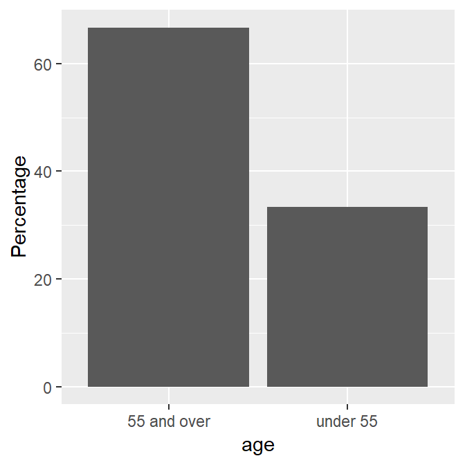

Fig. 1 - The Candidates by Age Groups

Table 2 - The Candidates by Gender

| Gender | Frequency |
| --- | --- |
| female | 5 |
| male | 31 |

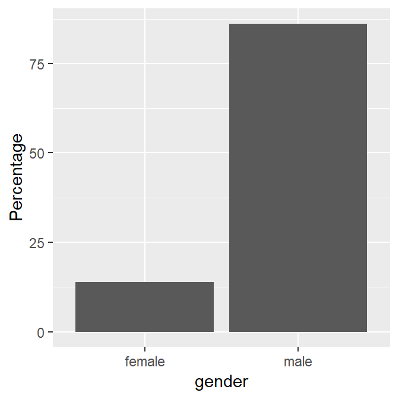

Fig. 2 - The Candidates by Gender

Table 3 - The Candidates by Region of Origin

| Region | Frequency |
| --- | --- |
| Amoron’i Mania | 2 |
| Analamanga | 18 |
| Antsinanana | 3 |
| Diana | 2 |
| Matsiatra Ambony | 4 |
| Menabe | 1 |
| Sava | 1 |
| Sofia | 2 |
| Vatovavy-Fitovinany | 3 |

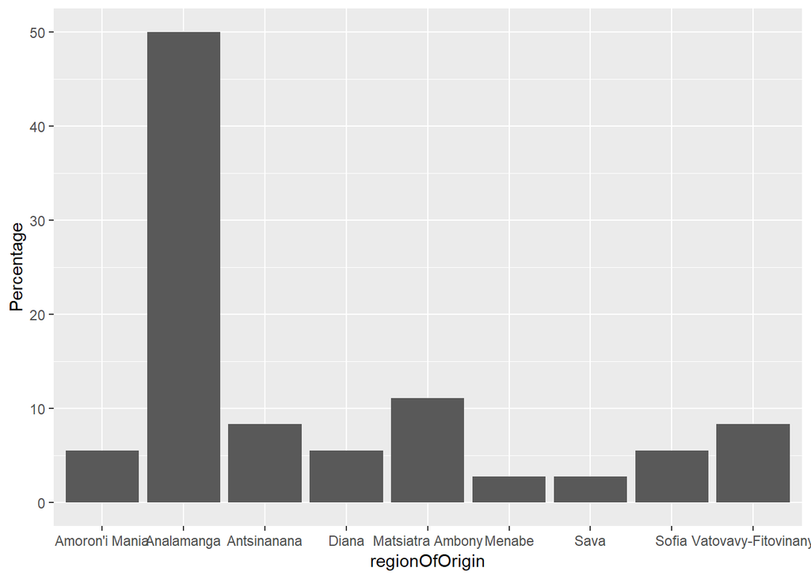

Fig. 3 - The Candidates by Region of Origin

Table 4 - The Candidates by Level of Education

| Level | Frequency |
| --- | --- |
| 11 | 1 |
| 12 | 1 |
| 14 | 1 |
| 15 | 2 |
| 16 | 10 |
| 18 | 13 |
| 20 | 6 |

```
##    Min. 1st Qu.  Median    Mean 3rd Qu.    Max.    NA's
##   11.00   16.00   18.00   17.09   18.00   20.00       2
```

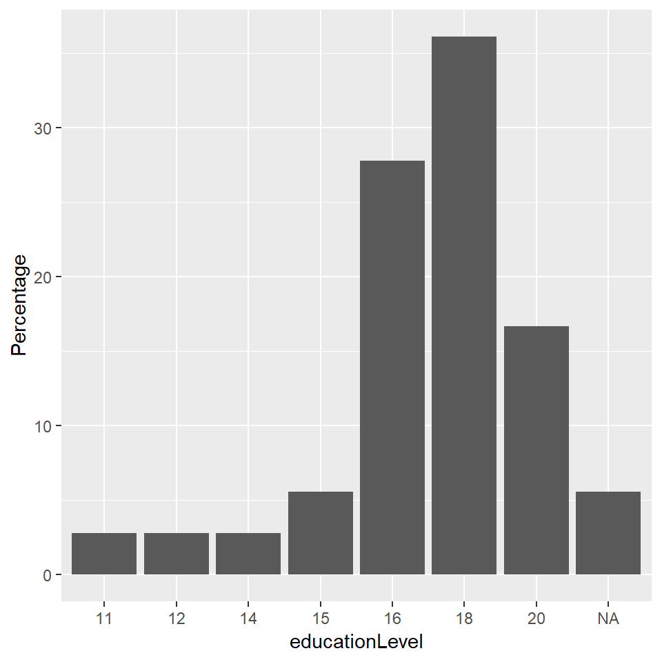

Fig. 4 - The Candidates by Level of Education

Table 5 - The Candidates by Academic Fields

| Academic Field | Frequency |
| --- | --- |
| accounting | 4 |
| biology | 1 |
| business administration | 3 |
| economics | 3 |
| engineering | 3 |
| history | 1 |
| law | 5 |
| medicine | 2 |
| military academy | 3 |
| no college education | 2 |
| physics | 2 |
| public administration | 2 |
| sociology | 3 |

| Major Campaign Issue | Frequency |
| --- | --- |
| cultural reform | 3 |
| economic reform | 8 |
| governance reform | 13 |
| no information | 6 |
| political system reform | 6 |

Table 6 - The Candidates by Government Experience

| Previous Government Position | Frequency |
| --- | --- |
| former member of the CSR | 1 |
| former member of the parliament | 2 |
| former minister | 7 |
| former president | 4 |
| former prime minister | 3 |
| no | 19 |

Table 8 - The Candidates by Major Means of Transportation

| Major Means of Transportation | Frequency |
| --- | --- |
| car | 31 |
| helicopter | 3 |
| motorcycle | 2 |

Table 9 - The Candidates by Number of Regions Covered

| Regions Covered by the Candidate | Frequency |
| --- | --- |
| about half | 7 |
| all 22 regions | 3 |
| few | 8 |
| very few | 18 |

Table 10 - Regions Covered by Means of Transportation

|  | about half | all 22 regions | few | very few |
| --- | --- | --- | --- | --- |
| car | 5 | 0 | 8 | 18 |
| helicopter | 0 | 3 | 0 | 0 |
| motorcycle | 2 | 0 | 0 | 0 |

## References